# Analiza i projektiranje računalom - 5. domaća zadaća

U okviru ove zadaće potrebno je ostvariti metode numeričke integracije po postupku **Runge-Kutta** 4. reda (*u skripti: str. 7-35*), **trapeznom** postupku, **Eulerovom** postupku, **obrnutom Eulerovom** postupku, i **prediktorsko-korektorskom** postupku. Sustav je općenitog oblika $\vec{x} = \vec{A}\vec{x} + \vec{B}\vec{r(t)}$. Program treba (iz datoteka) učitavati matrice linearnog sustava diferencijalnih jednadžbi ($\vec{A}$ i $\vec{B}$) te početno stanje $\vec{x}(t = 0)$. Za uporabu trapeznog i obrnutog Eulerovog postupka potrebno je zadani linearni sustav prethodno transformirati u eksplicitni oblik (*skripta 7-24, 25*).

Potrebno je bez prevođenja programa omogućiti zadavanje **željenog koraka integracije** (T) i **vremenskog intervala** za koji se provodi postupak $\left[ 0, t_{MAX} \right]$. Za prediktorsko-korektorski postupak potrebno je omogućiti da se bez prevođenja programa bilo koji dostupni eksplicitni postupak može koristiti kao prediktor, bilo koji implicitni postupak kao korektor te da je moguće definirati koliko puta će se korektor primijeniti. Program treba riješavati sustave svim sljedećim postupcima:

- Eulerovim
- obrnutim Eulerovim
- trapeznim
- Runge-Kutta 4. rede
- $\text{PE(CE)}^2$ (prediktor Euler, korektor obrnuti Euler)
- $\text{PECE}$ (prediktor Euler, korektor trapezni postupak)

Prilikom rada potrebno je ispisivati varijable stanja na ekran, no ne u svakoj iteraciji nego svakih nekoliko iteracija (omogućiti da taj broj zadaje korisnik). Osim na ekran, ispis je uputno preusmjeriti i u datoteku. Nakon završetka postupka potrebno je **grafički prikazati kretanje varijabli stanja** za oba postupka izračunavanja (vodoravna os je vrijeme, na uspravnoj su vrijednosti varijabli stanja). Crtanje se može izvesti bilo kojim pomoćnim alatom, npr. čitanjem izračunatih vrijednosti iz datoteke.

## Priprema za izvođenje

```python
import os

CD_KEY = "--HW05_IN_ROOT"
```

```python
if (
    CD_KEY not in os.environ
    or os.environ[CD_KEY] is None
    or len(os.environ[CD_KEY]) == 0
    or os.environ[CD_KEY] == "false"
):
    %cd ..
else:
    print(os.getcwd())

os.environ[CD_KEY] = "true"
```

```
/mnt/data/projekti/faks/AIPR/dz/dz-05
```

## Učitavanje paketa

```python
import warnings

from matplotlib import pyplot as plt
import numpy as np

from src.constants import SUB
from src.integrators.explicit import EulerIntegrator, RungeKutta4Integrator
from src.integrators.implicit import InverseEulerIntegrator, TrapezoidalIntegrator
from src.integrators.predictor_corrector import PredictorCorrectorIntegrator
from src.utils import get_state_over_time_graphs, print_diffs
```

```python
np.set_printoptions(precision=3, suppress=True)
np.random.seed(21051208)
warnings.filterwarnings('ignore')
```

## Zadatci

### Zadatak 1

Izračunajte ponašanje sljedećeg sustava:

$$ \begin{aligned} & \vec{x_{k+1}} = \begin{bmatrix} 0 & 1 \\ -1 & 0 \\ \end{bmatrix} \vec{x_{k}} & & \vec{x_0} = \begin{bmatrix} 1 \\ 1 \\ \end{bmatrix} & \end{aligned} $$

s periodom integracije $T = 0.01$ i $t_{MAX} = 10$ za sve zadane postupke. Sustav predstavlja matematičko njihalo, gdje je $x_{0_{0}}$ početni odmak od ravnotežnog položaja, a $x_{0_{1}}$ je početna brzina.

**Odgovor**

```python
t1_step = 0.01
t1_interval =(0, 10)

t1_a = np.array([
    [0, 1],
    [-1, 0],
])
t1_b = np.array([
    [0, 0],
    [0, 0],
])

t1_initial_state = np.array([
    [1],
    [1],
])

t1_steps_to_print = 100
```

```python
t1_integrators = (
    EulerIntegrator(),
    InverseEulerIntegrator(),
    TrapezoidalIntegrator(),
    RungeKutta4Integrator(),
    PredictorCorrectorIntegrator(
        predictor=EulerIntegrator(),
        corrector=InverseEulerIntegrator(),
    ),
    PredictorCorrectorIntegrator(
        predictor=EulerIntegrator(),
        corrector=TrapezoidalIntegrator(),
    ),
)

t1_results = dict()
```

```python
for integrator in t1_integrators[:-2]:
    t1_results[integrator.name] = integrator(
        step=t1_step,
        interval=t1_interval,
        initial_state=t1_initial_state,
        time_function=None,
        steps_to_print=t1_steps_to_print,
        a=t1_a,
        b=t1_b
    )
```

```
x_1000(t = 10.0) = [[-1.454 -0.311]]: : 1001it [00:00, 30358.34it/s]
x_1000(t = 10.0) = [[-1.316 -0.281]]: : 1001it [00:00, 23676.59it/s]
x_1000(t = 10.0) = [[-1.383 -0.295]]: : 1001it [00:00, 17091.04it/s]
x_1000(t = 10.0) = [[-1.383 -0.295]]: : 1001it [00:00, 12913.49it/s]
```

```python
for integrator, n_corrector_repeats in zip(t1_integrators[-2:], (2, 1)):
    t1_results[integrator.name] = integrator(
        step=t1_step,
        interval=t1_interval,
        initial_state=t1_initial_state,
        time_function=None,
        steps_to_print=t1_steps_to_print,
        a=t1_a,
        b=t1_b,
        n_corrector_repeats=n_corrector_repeats
    )
```

```
x_1000(t = 10.0) = [[-1.316 -0.281]]: : 1001it [00:00, 17171.07it/s]
x_1000(t = 10.0) = [[-1.383 -0.295]]: : 1001it [00:00, 19951.62it/s]
```

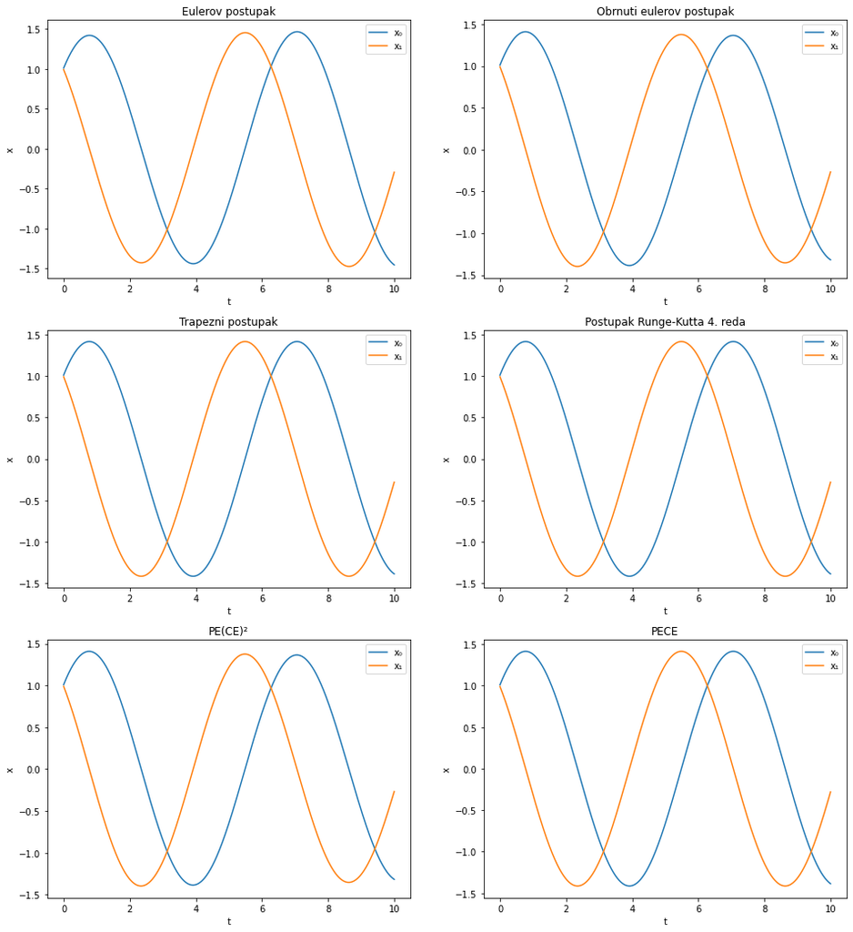

```python
t1_fig, t1_ax = get_state_over_time_graphs(t1_results)
```

Analitičko rješenje sustava je

$$ \begin{aligned} & \vec{x} = \begin{bmatrix} x_{0_{0}}\cos{t} + x_{0_{1}}\sin{t} \\ x_{0_{1}}\cos{t} - x_{0_{0}}\sin{t} \\ \end{bmatrix} & \end{aligned} $$

Za svaki postupak izračunajte kumulativnu pogrešku koju svaki od postupaka napravi tijekom izvođenja, na način da zbrojite apsolutnu razliku dobivenog i stvarnog rješenja u svakoj točki integracije, a zbroj prikažete na kraju izvođenja programa.

**Odgovor**

```python
t1_true_solutions = list()

for t in np.arange(t1_interval[0], t1_interval[1] + t1_step, t1_step):
    t1_true_solutions.append([
        [t1_initial_state[0][0] * np.cos(t) + t1_initial_state[1][0] * np.sin(t)],
        [t1_initial_state[1][0] * np.cos(t) - t1_initial_state[0][0] * np.sin(t)]
    ])

t1_true_solutions = np.array(t1_true_solutions)
```

```python
t1_diffs = dict()

for key, value in t1_results.items():
    t1_diffs[key] = np.zeros(shape=t1_true_solutions[0].shape)

    for state, true_solution in zip(value["states"], t1_true_solutions):
        t1_diffs[key] += abs(state["x"] - true_solution)
```

```python
print_diffs(t1_diffs, n_decimals=6)
```

```
Eulerov postupak:
	Δx₀ = 22.429695
	Δx₁ = 23.648003

Obrnuti eulerov postupak:
	Δx₀ = 21.728698
	Δx₁ = 22.824658

Trapezni postupak:
	Δx₀ = 0.038718
	Δx₁ = 0.036793

Postupak Runge-Kutta 4. reda:
	Δx₀ = 0.000000
	Δx₁ = 0.000000

PE(CE)²:
	Δx₀ = 21.732969
	Δx₁ = 22.829150

PECE:
	Δx₀ = 0.077510
	Δx₁ = 0.073529
```

Želimo li npr. dobiti sustav s prigušenjem, $\vec{A}_{2, 2}$ treba postaviti na negativnu vrijednost.

### Zadatak 2

Izračunajte ponašanje sljedećeg sustava:

$$ \begin{aligned} & \vec{x_{k+1}} = \begin{bmatrix} 0 & 1 \\ -200 & -102 \\ \end{bmatrix} \vec{x_{k}} & & \vec{x_0} = \begin{bmatrix} 1 \\ -2 \\ \end{bmatrix} & \end{aligned} $$

Sustav predstavlja fizikalno njihalo s prigušenjem (zadatak s predavanja). Isprobajte rješavanje s periodom integracije $T = 0.1$ i $t_{MAX} = 1$ za sve zadane postupke i obratite pažnju na numeričku stabilnost (uz zadane početne uvjete)!

**Odgovor**

```python
t2_step = 0.1
t2_interval =(0, 1)

t2_a = np.array([
    [0, 1],
    [-200, -102],
])
t2_b = np.array([
    [0, 0],
    [0, 0],
])

t2_initial_state = np.array([
    [1],
    [-2],
])

t2_steps_to_print = 1
```

```python
t2_integrators = (
    EulerIntegrator(),
    InverseEulerIntegrator(),
    TrapezoidalIntegrator(),
    RungeKutta4Integrator(),
    PredictorCorrectorIntegrator(
        predictor=EulerIntegrator(),
        corrector=InverseEulerIntegrator(),
    ),
    PredictorCorrectorIntegrator(
        predictor=EulerIntegrator(),
        corrector=TrapezoidalIntegrator(),
    ),
)

t2_results = dict()
```

```python
for integrator in t2_integrators[:-2]:
    t2_results[integrator.name] = integrator(
        step=t2_step,
        interval=t2_interval,
        initial_state=t2_initial_state,
        time_function=None,
        steps_to_print=t2_steps_to_print,
        a=t2_a,
        b=t2_b
    )
```

```
x_10(t = 1.0) = [[ 0.107 -0.215]]: : 11it [00:00, 676.92it/s]
x_10(t = 1.0) = [[ 0.162 -0.323]]: : 11it [00:00, 1272.33it/s]
x_10(t = 1.0) = [[ 0.134 -0.269]]: : 11it [00:00, 870.81it/s]
x_10(t = 1.0) = [[   852109.551 -85210941.861]]: : 11it [00:00, 810.32it/s]
```

```python
for integrator, n_corrector_repeats in zip(t2_integrators[-2:], (2, 1)):
    t2_results[integrator.name] = integrator(
        step=t2_step,
        interval=t2_interval,
        initial_state=t2_initial_state,
        time_function=None,
        steps_to_print=t2_steps_to_print,
        a=t2_a,
        b=t2_b,
        n_corrector_repeats=n_corrector_repeats
    )
```

```
x_10(t = 1.0) = [[ 8.961e+11 -8.961e+13]]: : 11it [00:00, 886.51it/s]
x_10(t = 1.0) = [[ 0.177 -4.232]]: : 11it [00:00, 1193.66it/s]
```

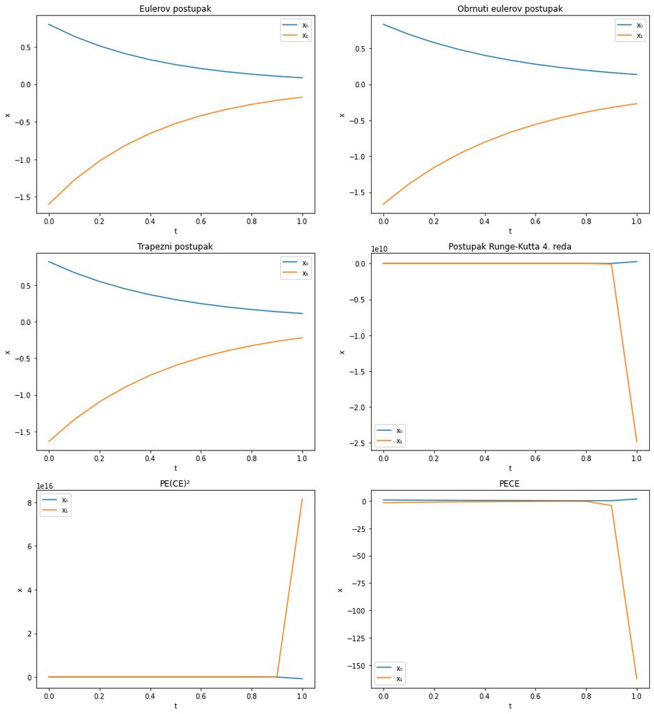

```python
t2_fig, t2_ax = get_state_over_time_graphs(t2_results)
```

**Komentar**

Vidimo da su ovdje stabilni bili jedino Eulerov, obrnuti Eulerov i trapezni postupak.

*Usporedbom rezultata odredite prikladni korak integracije za Runge-Kutta postupak.*

**Odgovor**

Čini se da je potreban nešto finiji korak integracije.

```python
t2_step_candidates = [(0.1 / (2 ** x)) for x in range(1, 4)]

t2_rk_integrator = [x for x in t2_integrators if x.name == "RungeKutta4Integrator"][0]
t2_rk_results = dict()
```

```python
for step in t2_step_candidates:
    t2_rk_results[step] = t2_rk_integrator(
        step=step,
        interval=t2_interval,
        initial_state=t2_initial_state,
        time_function=None,
        steps_to_print=t2_steps_to_print,
        a=t2_a,
        b=t2_b
    )
```

```
x_20(t = 1.0) = [[   64137.261 -6413712.818]]: : 21it [00:00, 967.09it/s]
x_40(t = 1.0) = [[ 0.135 -0.271]]: : 41it [00:00, 644.24it/s]
x_80(t = 1.0) = [[ 0.135 -0.271]]: : 81it [00:00, 762.39it/s]
```

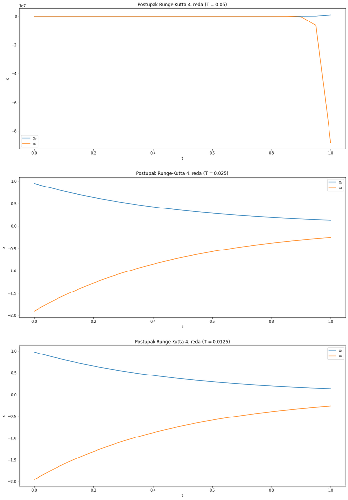

```python
t2_fig_rk, t2_ax_rk = plt.subplots(
    len(t2_step_candidates),
    1,
    figsize=(16, len(t2_step_candidates * 8))
)

for i, (step, results) in enumerate(t2_rk_results.items()):
    x_axis = [x["t"] for x in results["states"]]
    y_axis = np.array([x["x"] for x in results["states"]])
    y_axis = y_axis.reshape(len(y_axis), -1).T

    t2_ax_rk[i].set_title(f"Postupak Runge-Kutta 4. reda (T = {step})")
    t2_ax_rk[i].set_xlabel("t")
    t2_ax_rk[i].set_ylabel("x")

    for index, y in enumerate(y_axis):
        t2_ax_rk[i].plot(x_axis, y, label=f"x{str(index).translate(SUB)}")

    t2_ax_rk[i].legend()
```

**Komentar**

Vidimo da smo postigli stabilnost već za $T = 0.025$.

### Zadatak 3

Izračunajte ponašanje sljedećeg sustava:

$$ \begin{aligned} & \vec{x_{k+1}} = \begin{bmatrix} 0 & -2 \\ 1 & -3 \\ \end{bmatrix} \vec{x_{k}} + \begin{bmatrix} 2 & 0 \\ 0 & 3 \\ \end{bmatrix} \begin{bmatrix} 1 \\ 1 \\ \end{bmatrix} & & \vec{x_0} = \begin{bmatrix} 1 \\ 3 \\ \end{bmatrix} & \end{aligned} $$

Isprobajte rješavanje s periodom integracije $T = 0.01$ i $t_{MAX} = 10$ za sve zadane postupke.

**Odgovor**

```python
t3_step = 0.01
t3_interval =(0, 10)

t3_a = np.array([
    [0, -2],
    [1, -3],
])
t3_b = np.array([
    [2, 0],
    [0, 3],
])
t3_time_function = lambda t: np.array([
    [1],
    [1],
])

t3_initial_state = np.array([
    [1],
    [3],
])

t3_steps_to_print = 100
```

```python
t3_integrators = (
    EulerIntegrator(),
    InverseEulerIntegrator(),
    TrapezoidalIntegrator(),
    RungeKutta4Integrator(),
    PredictorCorrectorIntegrator(
        predictor=EulerIntegrator(),
        corrector=InverseEulerIntegrator(),
    ),
    PredictorCorrectorIntegrator(
        predictor=EulerIntegrator(),
        corrector=TrapezoidalIntegrator(),
    ),
)

t3_results = dict()
```

```python
for integrator in t3_integrators[:-2]:
    t3_results[integrator.name] = integrator(
        step=t3_step,
        interval=t3_interval,
        initial_state=t3_initial_state,
        time_function=t3_time_function,
        steps_to_print=t3_steps_to_print,
        a=t3_a,
        b=t3_b
    )
```

```
x_1000(t = 10.0) = [[-0.  1.]]: : 1001it [00:00, 12600.72it/s]
x_1000(t = 10.0) = [[-0.  1.]]: : 1001it [00:00, 16641.42it/s]
x_1000(t = 10.0) = [[-0.  1.]]: : 1001it [00:00, 18499.74it/s]
x_1000(t = 10.0) = [[-0.  1.]]: : 1001it [00:00, 8098.85it/s]
```

```python
for integrator, n_corrector_repeats in zip(t3_integrators[-2:], (2, 1)):
    t3_results[integrator.name] = integrator(
        step=t3_step,
        interval=t3_interval,
        initial_state=t3_initial_state,
        time_function=t3_time_function,
        steps_to_print=t3_steps_to_print,
        a=t3_a,
        b=t3_b,
        n_corrector_repeats=n_corrector_repeats
    )
```

```
x_1000(t = 10.0) = [[-0.  1.]]: : 1001it [00:00, 10923.15it/s]
x_1000(t = 10.0) = [[-0.  1.]]: : 1001it [00:00, 12259.82it/s]
```

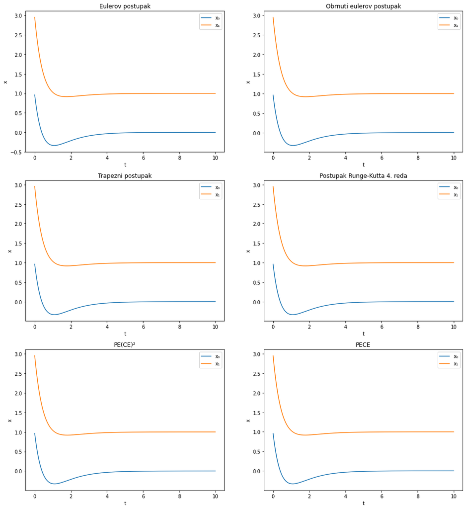

```python
t3_fig, t3_ax = get_state_over_time_graphs(t3_results)
```

### Zadatak 4

Izračunajte ponašanje sljedećeg sustava:

$$ \begin{aligned} & \vec{x_{k+1}} = \begin{bmatrix} 1 & -5 \\ 1 & -7 \\ \end{bmatrix} \vec{x_{k}} + \begin{bmatrix} 5 & 0 \\ 0 & 3 \\ \end{bmatrix} \begin{bmatrix} t \\ t \\ \end{bmatrix} & & \vec{x_0} = \begin{bmatrix} -1 \\ 3 \\ \end{bmatrix} & \end{aligned} $$

**Odgovor**

```python
t4_step = 0.01
t4_interval =(0, 1)

t4_a = np.array([
    [1, -5],
    [1, -7],
])
t4_b = np.array([
    [5, 0],
    [0, 3],
])
t4_time_function = lambda t: np.array([
    [t],
    [t],
])

t4_initial_state = np.array([
    [-1],
    [3],
])

t4_steps_to_print = 100
```

```python
t4_integrators = (
    EulerIntegrator(),
    InverseEulerIntegrator(),
    TrapezoidalIntegrator(),
    RungeKutta4Integrator(),
    PredictorCorrectorIntegrator(
        predictor=EulerIntegrator(),
        corrector=InverseEulerIntegrator(),
    ),
    PredictorCorrectorIntegrator(
        predictor=EulerIntegrator(),
        corrector=TrapezoidalIntegrator(),
    ),
)

t4_results = dict()
```

```python
for integrator in t4_integrators[:-2]:
    t4_results[integrator.name] = integrator(
        step=t4_step,
        interval=t4_interval,
        initial_state=t4_initial_state,
        time_function=t4_time_function,
        steps_to_print=t4_steps_to_print,
        a=t4_a,
        b=t4_b
    )
```

```
x_100(t = 1.0) = [[-2.588 -0.04 ]]: : 101it [00:00, 19094.24it/s]
x_100(t = 1.0) = [[-2.546 -0.032]]: : 101it [00:00, 11270.81it/s]
x_100(t = 1.0) = [[-2.567 -0.036]]: : 101it [00:00, 11787.00it/s]
x_100(t = 1.0) = [[-2.567 -0.036]]: : 101it [00:00, 7124.89it/s]
```

```python
for integrator, n_corrector_repeats in zip(t4_integrators[-2:], (2, 1)):
    t4_results[integrator.name] = integrator(
        step=t4_step,
        interval=t4_interval,
        initial_state=t4_initial_state,
        time_function=t4_time_function,
        steps_to_print=t4_steps_to_print,
        a=t4_a,
        b=t4_b,
        n_corrector_repeats=n_corrector_repeats
    )
```

```
x_100(t = 1.0) = [[-2.588 -0.042]]: : 101it [00:00, 10347.71it/s]
x_100(t = 1.0) = [[-2.567 -0.036]]: : 101it [00:00, 11254.04it/s]
```

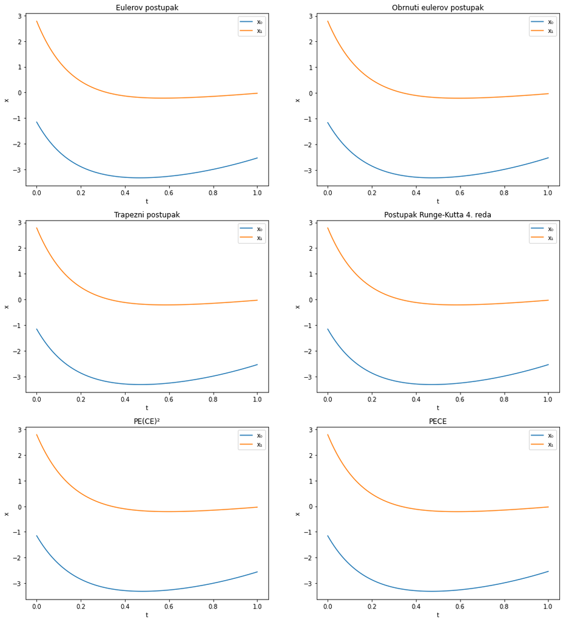

```python
t4_fig, t4_ax = get_state_over_time_graphs(t4_results)
```